# 326.212 Final Project: Part 2

## 2019 - 15993 Lee seung heon

## Part 2

### Q1

```r
Measurement_relational_info <- Measurement_relational_info %>% select(
-Station.code , -Address, -Latitude, -Longitude, -Item.code, -Unit.of.measurement, -Good.Blue., -Normal.Green., -Bad.Yellow., -Very.bad.Red.)
```

### Q2

```r
Measurement_relational_info$Measurement.date <- as.factor(Measurement_relational_info$Measurement.date)
Measurement_relational_info$Item.name <- as.factor(Measurement_relational_info$Item.name)
Measurement_relational_info$Station.name.district. <- as.factor(Measurement_relational_info$Station.name.district.)
Measurement_relational_info$Pollution_level <- as.factor(Measurement_relational_info$Pollution_level)
```

### Q3

#### 1.

```r
colSums(is.na(Measurement_relational_info))
```

```
##       Measurement.date          Average.value      Instrument.status
##                      0                      0                      0
##              Item.name Station.name.district.        Pollution_level
##                      0                      0                  26160
```

각 변수별 NA의 개수는 위 결과와 같다.

#### 2.

Pollution_level 변수에서 나온 결측치들은 Average.value가 음수이거나 임계치를 초과한 경우이다.

#### 3.

측정되어서는 안되는 값이 측정된 경우이므로 해당 데이터를 그냥 삭제하는 방식으로 처리하면 된다.

```r
Measurement_relational_info <- Measurement_relational_info %>% filter(!is.na(Pollution_level))
```

### Q4

#### 1.

```r
Instrument_ratio <- Measurement_relational_info %>% group_by(Instrument.status) %>% count()

Instrument_ratio %>% mutate(total = sum(Instrument_ratio$n), ratio = n/total)
```

```
## # A tibble: 6 x 4
## # Groups:   Instrument.status [6]
##   Instrument.status       n   total    ratio
##               <int>   <int>   <int>    <dbl>
## 1                 0 3775778 3858906 0.978
## 2                 1   28725 3858906 0.00744
## 3                 2    2857 3858906 0.000740
## 4                 4    3566 3858906 0.000924
## 5                 8   29108 3858906 0.00754
## 6                 9   18872 3858906 0.00489
```

#### 2.

Instrument status는 0: Normal, 1: Need for calibration, 2: Abnormal, 4: Power cut off, 8: Under repair, 9: abnormal data 이고 대략 98퍼센트의 측정치가 0에 속한다. 따라서 측정장치의 상태가 불량하여 신뢰할만한 측정치를 얻지 못한 것들을 고려하지 않고, Instrument status가 0인 행들만 다루는 것이 데이터를 분석하는 데에 더 좋다.

```r
Measurement_relational_info <- Measurement_relational_info %>% filter(Instrument.status == 0)
```

### Q5

```r
arranged_info <- Measurement_relational_info %>% arrange(Item.name, desc(Average.value))

rbind(arranged_info %>% filter(Item.name == 'PM10') %>% head(1),
      arranged_info %>% filter(Item.name == 'PM2.5') %>% head(1),
      arranged_info %>% filter(Item.name == 'SO2') %>% head(1),
      arranged_info %>% filter(Item.name == 'NO2') %>% head(1),
      arranged_info %>% filter(Item.name == 'CO') %>% head(1),
      arranged_info %>% filter(Item.name == 'O3') %>% head(1))
```

```
##   Measurement.date Average.value Instrument.status Item.name
## 1 2018-04-06 14:00       470.000                 0      PM10
## 2 2019-12-20 03:00       205.000                 0     PM2.5
## 3 2017-03-18 05:00         0.041                 0       SO2
## 4 2019-02-05 23:00         0.123                 0       NO2
## 5 2019-02-06 03:00         3.200                 0        CO
## 6 2019-02-05 23:00         0.215                 0        O3
##   Station.name.district. Pollution_level
## 1              Seocho-gu   Very bad(Red)
## 2            Gangdong-gu   Very bad(Red)
## 3                Guro-gu   Normal(Green)
## 4        Yeongdeungpo-gu     Bad(Yellow)
## 5              Dobong-gu   Normal(Green)
## 6        Yeongdeungpo-gu   Very bad(Red)
```

### Q6

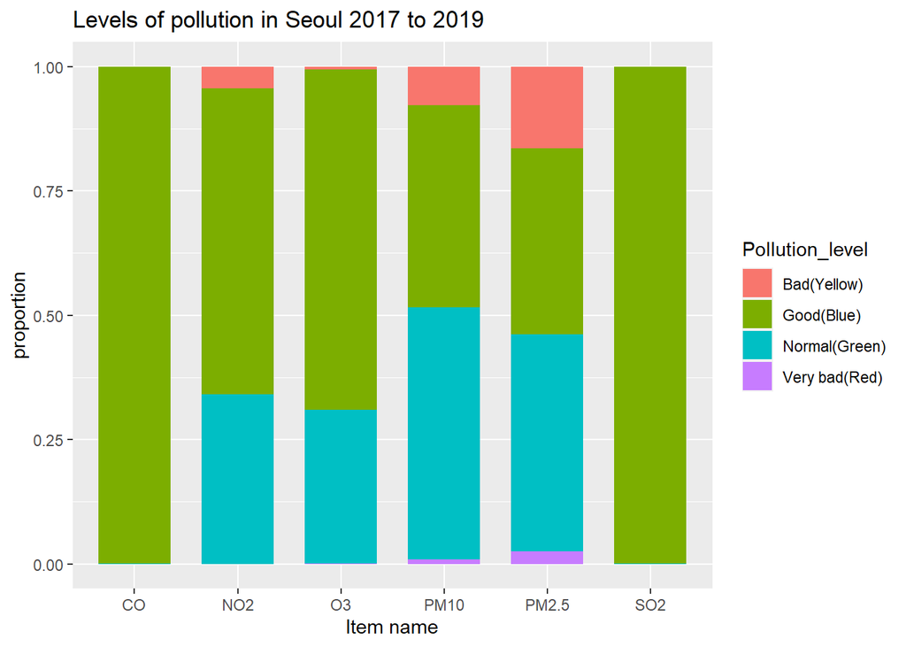

```r
ggplot(data = Measurement_relational_info ) +
   geom_bar(mapping = aes(x = Item.name, fill = Pollution_level), position = "fill", width = 0.7) +
   labs(title = "Levels of pollution in Seoul 2017 to 2019", x = "Item name", y = "proportion")
```

### Q7

```r
head(Measurement_relational_info)
```

```
##   Measurement.date Average.value Instrument.status Item.name
## 1 2017-01-01 00:00         0.004                 0       SO2
## 2 2017-01-01 00:00         0.059                 0       NO2
## 3 2017-01-01 00:00         1.200                 0        CO
## 4 2017-01-01 00:00         0.002                 0        O3
## 5 2017-01-01 00:00        73.000                 0      PM10
## 6 2017-01-01 00:00        57.000                 0     PM2.5
##   Station.name.district. Pollution_level
## 1              Jongno-gu      Good(Blue)
## 2              Jongno-gu   Normal(Green)
## 3              Jongno-gu      Good(Blue)
## 4              Jongno-gu      Good(Blue)
## 5              Jongno-gu   Normal(Green)
## 6              Jongno-gu     Bad(Yellow)
```

### Q8

```r
Measurement_relational_info %>% filter(Item.name == "PM2.5") %>% group_by(Station.name.district.) %>% summarise(mean(Average.value)) %>% arrange(`mean(Average.value)`)
```

```
## # A tibble: 25 x 2
##    Station.name.district. `mean(Average.value)`
##    <fct>                                  <dbl>
##  1 Gangbuk-gu                              21.8
##  2 Jongno-gu                               22.6
##  3 Dobong-gu                               22.8
##  4 Jungnang-gu                             22.9
##  5 Jung-gu                                 22.9
##  6 Songpa-gu                               23.0
##  7 Seongbuk-gu                             23.1
##  8 Dongdaemun-gu                           23.5
##  9 Seocho-gu                               23.6
## 10 Yongsan-gu                              23.6
## # ... with 15 more rows
```

위 결과를 보면 3 년간 초미세먼지(PM2.5) 평균 배출량이 가장 낮은 구는 강북구이고, 가장 높은 구는 관악구이다.

### Q9

```r
x<-Measurement_relational_info %>% filter(Item.name == "PM2.5") %>% filter(Station.name.district.=="Gwanak-gu")
y<-Measurement_relational_info %>% filter(Item.name == "PM2.5") %>% filter(Station.name.district.=="Gangbuk-gu")
t.test(x$Average.value, y$Average.value)
```

```
##
##  Welch Two Sample t-test
##
## data:  x$Average.value and y$Average.value
## t = 30.964, df = 47726, p-value < 2.2e-16
## alternative hypothesis: true difference in means is not equal to 0
## 95 percent confidence interval:
##  5.032470 5.712627
## sample estimates:
## mean of x mean of y
##  27.14079  21.76824
```

p-vlaue가 2.2e-16보다 작으므로 유의수준 0.05에서 두 개의 구의 초미세먼지 평균 배출량의 차이는 유의하다.

### Q10

```r
Year <- Measurement_relational_info$Measurement.date %>% year()
Month <-Measurement_relational_info$Measurement.date %>% month()
Day <- Measurement_relational_info$Measurement.date %>% day()
Hour <- Measurement_relational_info$Measurement.date %>% hour()
```

```r
Year <- tibble(Year)
Month <- tibble(Month)
Day <- tibble(Day)
Hour <- tibble(Hour)
Measurement_relational_info <- cbind(Year, Month, Day, Hour, Measurement_relational_info)
```

### Q11

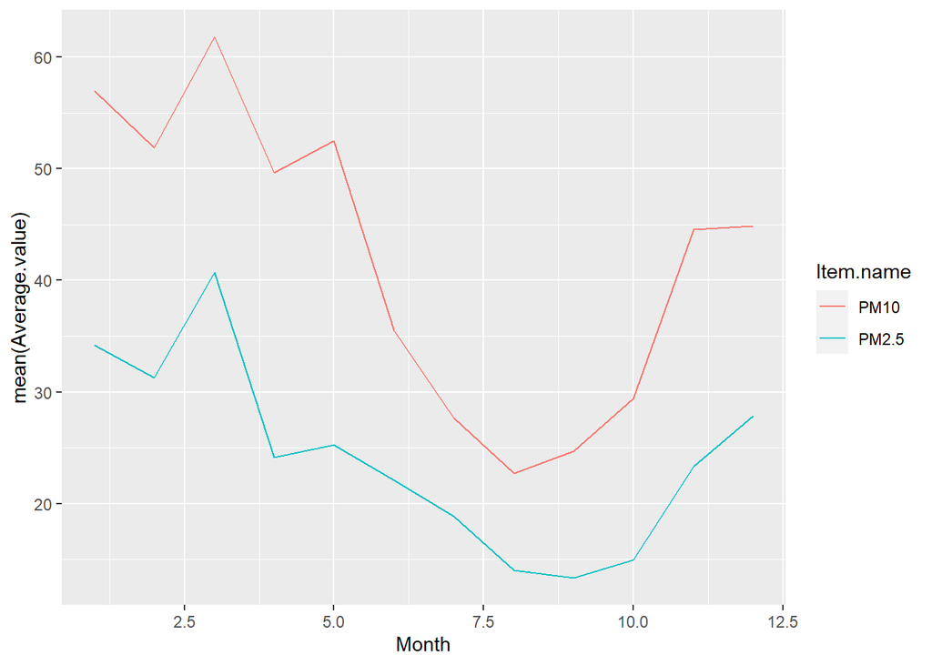

```r
monthly_PM <- Measurement_relational_info %>% filter(Item.name == "PM10" | Item.name == "PM2.5") %>% group_by(Month, Item.name) %>% summarise(mean(Average.value))
ggplot(data = monthly_PM) + geom_line(aes(Month,`mean(Average.value)`, color = Item.name), show.legend = T)
```

### Q12

#### 1.

```r
spread_item <- Measurement_relational_info %>% select(Measurement.date, Station.name.district., Item.name, Average.value) %>% spread(key = Item.name, value = Average.value) %>% select(-Measurement.date, -Station.name.district.)
head(spread_item)
```

```
##    CO   NO2    O3 PM10 PM2.5   SO2
## 1 0.9 0.051 0.002   81    40 0.006
## 2 1.1 0.052 0.002   76    50 0.006
## 3 1.2 0.062 0.002   63    49 0.006
## 4 0.6 0.045 0.003   73    46 0.005
## 5 1.2 0.046 0.001   63    51 0.004
## 6 0.9 0.042 0.002   68    53 0.004
```

#### 1.

```r
spread_item<-spread_item %>% na.omit()
colSums(is.na(spread_item))
```

```
##    CO   NO2    O3  PM10 PM2.5   SO2
##     0     0     0     0     0     0
```

#### 2.

```r
cor(spread_item)
```

```
##               CO        NO2          O3       PM10       PM2.5         SO2
## CO     1.0000000  0.6863144 -0.36677723 0.49762110  0.59684868  0.31857302
## NO2    0.6863144  1.0000000 -0.49158796 0.43137522  0.50149894  0.31909712
## O3    -0.3667772 -0.4915880  1.00000000 0.02924718 -0.02780642 -0.01655776
## PM10   0.4976211  0.4313752  0.02924718 1.00000000  0.82580808  0.37837514
## PM2.5  0.5968487  0.5014989 -0.02780642 0.82580808  1.00000000  0.37965985
## SO2    0.3185730  0.3190971 -0.01655776 0.37837514  0.37965985  1.00000000
```

#### 3.

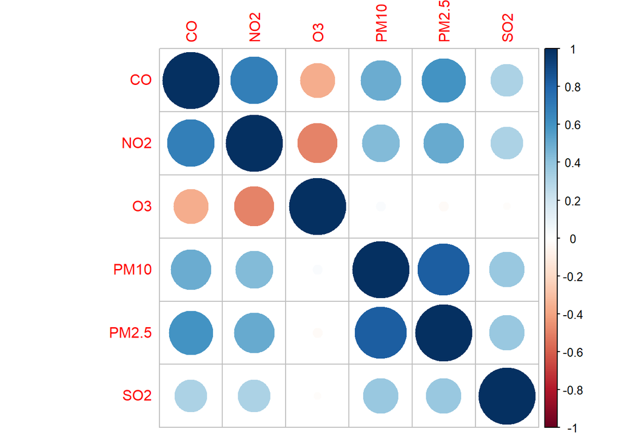

```r
corrplot(cor(spread_item))
```

양의 상관관계 : (CO, PM10), (CO, PM2.5), (CO, NO2), (NO2, PM10), (NO2,PM2.5), (PM10, PM2.5)

약한 양의 상관관계 : (CO, SO2), (NO2, SO2), (PM10, SO2), (PM2.5, SO2)

음의 상관관계: (NO2, O3)

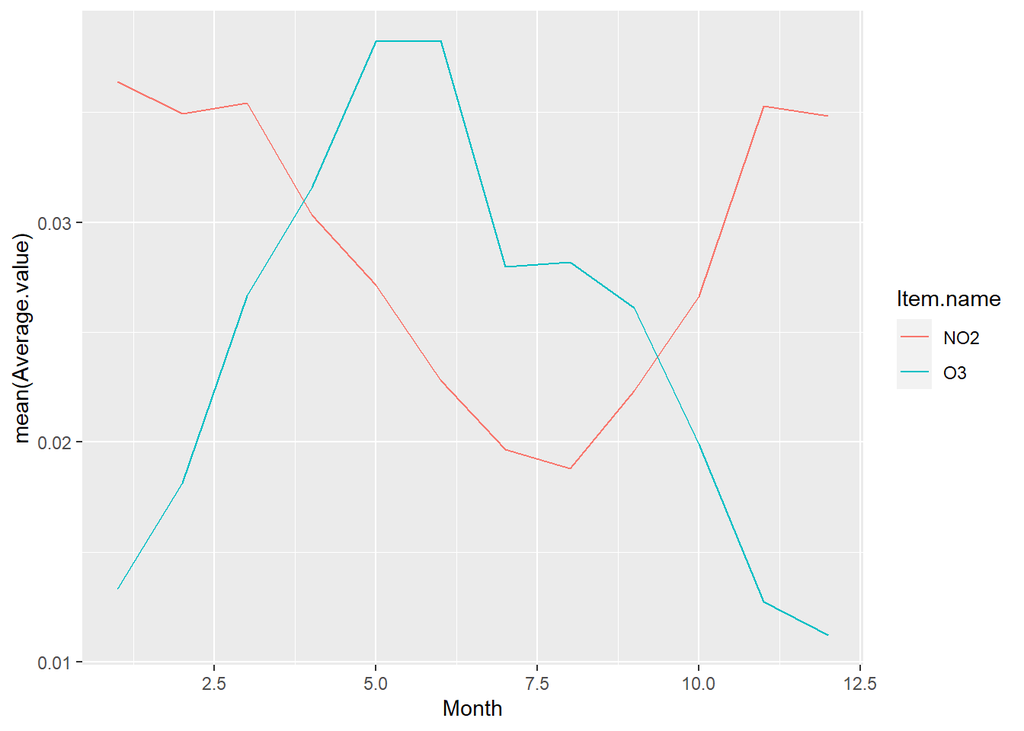

```r
monthly <- Measurement_relational_info %>% filter(Item.name == "NO2" | Item.name == "O3") %>% group_by(Month, Item.name) %>% summarise(mean(Average.value))

ggplot(data = monthly) + geom_line(aes(Month, `mean(Average.value)`, color=Item.name),show.legend = T)
```

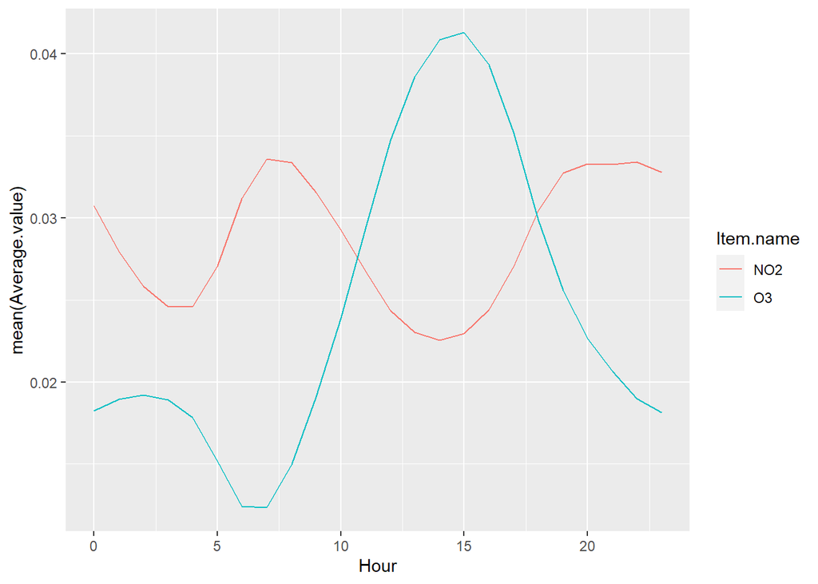

```r
hourly <- Measurement_relational_info %>% filter(Item.name == "NO2" | Item.name == "O3") %>% group_by(Hour, Item.name) %>% summarise(mean(Average.value))

ggplot(data = hourly) + geom_line(aes(Hour, `mean(Average.value)`, color=Item.name),show.legend = T)
```